# DESeq2 Analysis of mRNA data: Final

Data in this file used for final analysis. If analyses need to change, DELETE FROM THIS FILE

Import: Raw counts data, enter in sample information (TTN+, TTN-, or Controls) Export: DESeq2 results Graphs: PCA, heatmap of DEGs

Import libraries:

```r
suppressPackageStartupMessages(library(DESeq2))
suppressPackageStartupMessages(library(viridis))
suppressPackageStartupMessages(library(RColorBrewer))
suppressPackageStartupMessages(library(pheatmap))
suppressPackageStartupMessages(library(ggplot2))
```

Import and preprocess data:

```r
#set working directory
wd<- "//Cifs2/rcdata$/UKRNASeq/"

#read in count data
countsInput<- read.csv(paste(wd, "RawCounts/CountData.csv", sep =""))

#reformat Counts data
rownames(countsInput)<- countsInput$X
countsInput<- countsInput[,-1]

#Rename column data
colnames(countsInput)<- gsub(".counts.*", "", colnames(countsInput))

#Get rid of any genes with NA values, or where counts are 0 for that gene across all samples
counts<- na.omit(countsInput)
counts<- counts[rowSums(counts)>0,]
```

Create Metadata and DESeq2 Object

```r
#Read in metadata info, select just samples to be used- excluding sample 4, 10, and 14 (either no good exome or RNASeq data)
meta<- read.csv(paste(wd, "MetaData_AllSamples.csv",sep=""))
rownames(meta)<- meta$Sample
meta<- meta[,-1]
meta<- meta[!(rownames(meta) %in% c(paste("X", c(4,10,14), sep=""))),]

#check that counts/meta data has samples in same order
all(rownames(meta) %in% colnames(counts))
all(rownames(meta) == colnames(counts))

#create DESeq2 object
dds<- DESeqDataSetFromMatrix(countData=counts,
                             colData=meta,
                             design=~sampleGroup)

#define levels- so that controls will always be used as reference group
dds$sampleGroup<- relevel(dds$sampleGroup, ref= "control")
```

Normalize data by running DESeq2, visualize sample clustering with PCA plot

```r
#run DE
dds<- DESeq(dds)
```

```
-- replacing outliers and refitting for 22 genes
-- DESeq argument 'minReplicatesForReplace' = 7
-- original counts are preserved in counts(dds)
```

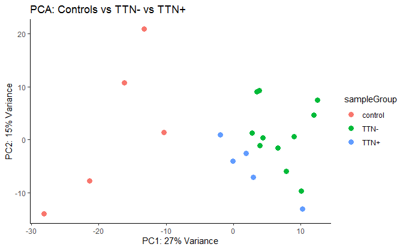

```r
#Normalize using variance stabilizing transformation- DESeq2 function
vsd <- vst(dds, blind=FALSE)
PCAData<-plotPCA(vsd, intgroup="sampleGroup", returnData=TRUE)
PCAData$sampleGroup<- gsub("pos", "TTN+", PCAData$sampleGroup)
PCAData$sampleGroup<- gsub("neg", "TTN-", PCAData$sampleGroup)

p<-ggplot(PCAData, aes(x=PC1, y=PC2, color=sampleGroup))+
  geom_point(size=3)+
  xlab("PC1: 27% Variance")+
  ylab("PC2: 15% Variance")+
  ggtitle("PCA: Controls vs TTN- vs TTN+")+
  theme_classic()

p
```

```r
#function that takes dds object and desired contrasts as input, outputs ordered results

ContrastDGE<- function(contrasts, dds){
  ContrastsUse<- c("sampleGroup", contrasts)
  ContrastsResults<- na.omit(results(dds, contrast=ContrastsUse))
  resOrdered<- ContrastsResults[order(ContrastsResults$padj),]
  return(resOrdered)
}

#Extract comparisons for 3 desired groups
DGERes_controlpos<- ContrastDGE(c("control", "pos"), dds)
DGERes_controlneg<- ContrastDGE(c("control", "neg"), dds)
DGERes_posneg<- ContrastDGE(c("pos", "neg"), dds)

nrow(DGERes_controlpos[DGERes_controlpos$padj<0.05,])
nrow(DGERes_controlneg[DGERes_controlneg$padj<0.05,])
nrow(DGERes_posneg[DGERes_posneg$padj<0.05,])
```

1507 DEGs in TTN+ vs controls 4427 DEGs in TTN- vs controls 50 DEGs in TTN+ vs TTN-

Write to csv file for later use

```r
write.csv(as.data.frame(DGERes_controlpos), paste(wd, "DESeq2/Final/", "DGERes_controlvspos_111219.csv", sep = ""))
write.csv(as.data.frame(DGERes_controlneg), paste(wd, "DESeq2/Final/", "DGERes_controlvsneg_111219.csv", sep = ""))
write.csv(as.data.frame(DGERes_posneg), paste(wd, "DESeq2/Final/", "DGERes_posvsneg_111219.csv", sep = ""))
```

#Plotting 3 different heatmaps:

1. for controls vs pos/ controls vs neg analysis
2. for pos vs neg analysis
3. for list of genes from ALL THREE analyses

```r
#normalize for heatmap plotting
rld<- rlog(dds)
```

#Heatmap 1- for just control vs pos or neg, top 75 genes in each

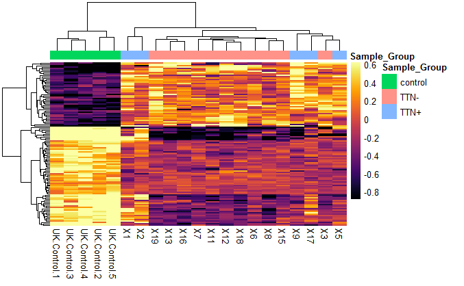

```r
#select top 75 DE genes for control vs pos or neg, and all of sig DE
topgenes<- unique(c(rownames(DGERes_controlneg[1:75,]), rownames(DGERes_controlpos[1:75,])))

#settings for heatmap
subtractFromMin<- -.7
subtractFromMax<- 2.75
lengthOut<- 100

mat<- assay(rld)[topgenes,]
mat<- mat - rowMeans(mat)
mat_breaks<- seq(min(mat-subtractFromMin), max(mat-subtractFromMax), length.out=lengthOut)


#Create metadata- to be used to color code to show which group the sample belongs to
metadata<- data.frame(Sample_Group=PCAData$sampleGroup, row.names=PCAData$name)

#plot heatmap
pheatmap(mat, breaks = mat_breaks, color =inferno(length(mat_breaks-1)), show_rownames = FALSE, annotation_col = metadata, border_color= NA)
```

#heatmap 2- for just the pos vs neg analysis- top 75 genes

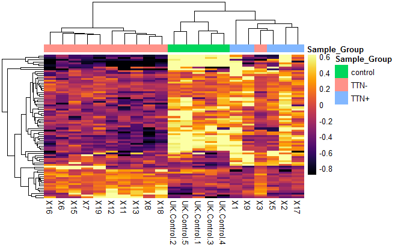

```r
#settings for heatmap
subtractFromMin<- -.7
subtractFromMax<- 2.75
lengthOut<- 100
mat_breaks<- seq(min(mat-subtractFromMin), max(mat-subtractFromMax), length.out=lengthOut)

#select top 75 DE genes in pos vs neg analysis
topgenes<- rownames(DGERes_posneg[1:75,])

mat<- assay(rld)[topgenes,]
mat<- mat - rowMeans(mat)

#Create metadata- to be used to color code to show which group the sample belongs to
metadata<- data.frame(Sample_Group=PCAData$sampleGroup, row.names=PCAData$name)

#plot heatmap
pheatmap(mat, breaks = mat_breaks, color =inferno(length(mat_breaks-1)), show_rownames = FALSE, annotation_col = metadata, border_color = NA)
```

#heatmap 3- using list of genes taken from all three analysis- top 75 of control vs pos, control vs neg, and pos vs neg

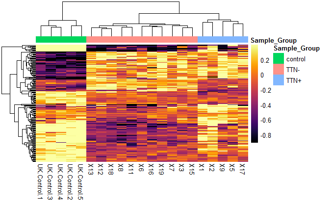

```r
#settings for heatmap
subtractFromMin<- -.7
subtractFromMax<- 2.75
lengthOut<- 100
mat_breaks<- seq(min(mat-subtractFromMin), max(mat-subtractFromMax), length.out=lengthOut)

#select top 75 DE genes for control vs pos or neg and pos vs neg
topgenes<- unique(c(rownames(DGERes_controlneg[1:75,]), rownames(DGERes_controlpos[1:75,])))
topgenes<- unique(c(topgenes, rownames(DGERes_posneg[1:75,])))

mat<- assay(rld)[topgenes,]
mat<- mat - rowMeans(mat)

#Create metadata- to be used to color code to show which group the sample belongs to
metadata<- data.frame(Sample_Group=PCAData$sampleGroup, row.names=PCAData$name)

#plot heatmap
pheatmap(mat, breaks = mat_breaks, color =inferno(length(mat_breaks-1)), show_rownames = FALSE, annotation_col = metadata, border_color=NA)
```

#Volcano plots- plotting padj vs log2FC

3 plots: Controls vs Pos results, Controls vs Neg results, and Pos vs Neg results

Controls vs Pos

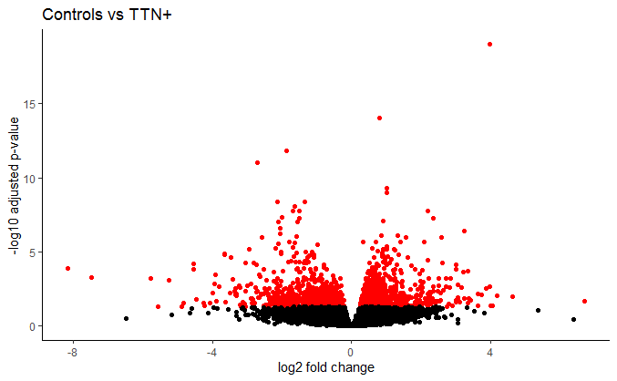

```r
#rename controls vs pos for use here
CvP<- as.data.frame(DGERes_controlpos)
threshold_OE<- CvP$padj<0.05
CvP$threshold<- threshold_OE


p<-ggplot(CvP) +
        geom_point(aes(x=log2FoldChange, y=-log10(padj), colour=threshold)) +
        ggtitle("Controls vs TTN+") +
        xlab("log2 fold change") +
        ylab("-log10 adjusted p-value") +
        #scale_y_continuous(limits = c(0,50)) +
        theme(legend.position = "none",
              plot.title = element_text(size = rel(1.5), hjust = 0.5),
              axis.title = element_text(size = rel(1.25)))+
        scale_color_manual(values= c("black", "red"))+
        theme_classic()+
        theme(legend.position="none")
p
```

Controls vs Neg

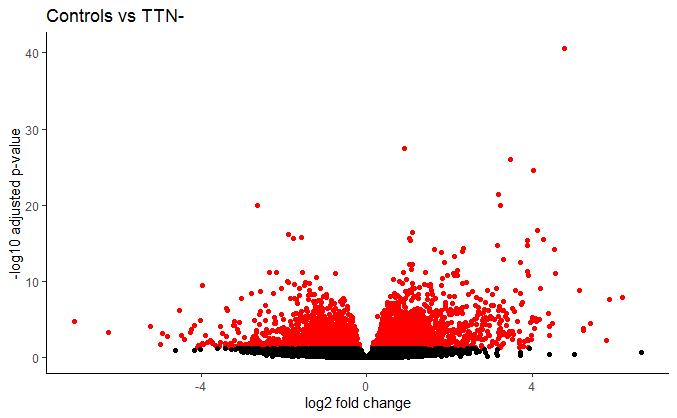

```r
#rename controls vs neg for use here
CvN<- as.data.frame(DGERes_controlneg)
threshold_OE<- CvN$padj<0.05
CvN$threshold<- threshold_OE


p<-ggplot(CvN) +
        geom_point(aes(x=log2FoldChange, y=-log10(padj), colour=threshold)) +
        ggtitle("Controls vs TTN-") +
        xlab("log2 fold change") +
        ylab("-log10 adjusted p-value") +
        #scale_y_continuous(limits = c(0,50)) +
        theme(legend.position = "none",
              plot.title = element_text(size = rel(1.5), hjust = 0.5),
              axis.title = element_text(size = rel(1.25)))+
        scale_color_manual(values= c("black", "red"))+
        theme_classic()+
        theme(legend.position="none")
p
```

Pos vs Neg

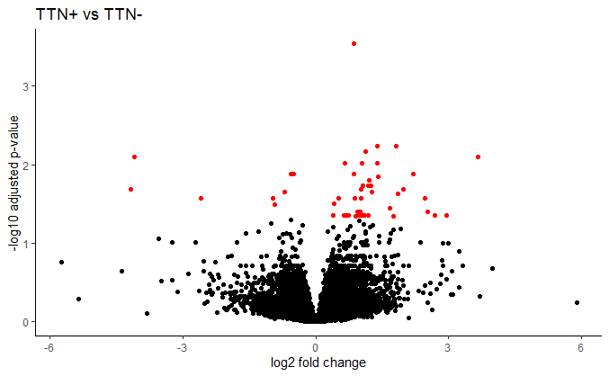

```r
#rename neg vs pos for use here
PvN<- as.data.frame(DGERes_posneg)
threshold_OE<- PvN$padj<0.05
PvN$threshold<- threshold_OE


p<-ggplot(PvN) +
        geom_point(aes(x=log2FoldChange, y=-log10(padj), colour=threshold)) +
        ggtitle("TTN+ vs TTN-") +
        xlab("log2 fold change") +
        ylab("-log10 adjusted p-value") +
        #scale_y_continuous(limits = c(0,50)) +
        theme(legend.position = "none",
              plot.title = element_text(size = rel(1.5), hjust = 0.5),
              axis.title = element_text(size = rel(1.25)))+
        scale_color_manual(values= c("black", "red"))+
        theme_classic()+
        theme(legend.position="none")
p
```

#TTN+ and TTN- specific DEGs

TTN+ vs TTN- analysis not considered here

Overall results of this section: samples don’t cluster well when you only look at TTN+/TTN- specific DEGs.

Select genes that are DE in controls vs TTN+ but NOT in controls vs TTN-, and vice versa

```r
posSig<- as.data.frame(DGERes_controlpos[DGERes_controlpos$padj<0.05,])
negSig<- as.data.frame(DGERes_controlneg[DGERes_controlneg$padj<0.05,])

posOnly<- posSig[!(rownames(posSig) %in% rownames(negSig)),]
negOnly<- negSig[!(rownames(negSig) %in% rownames(posSig)),]

nrow(posOnly)
```

```
[1] 205
```

```r
nrow(negOnly)
```

```
[1] 3125
```

205 TTN+ specific DEGs 3125 TTN- specific DEGs

#Plot heatmap of ONLY these TTN+/TTN- specific genes Use all TTN+ specific genes, and top half of TTN- specific

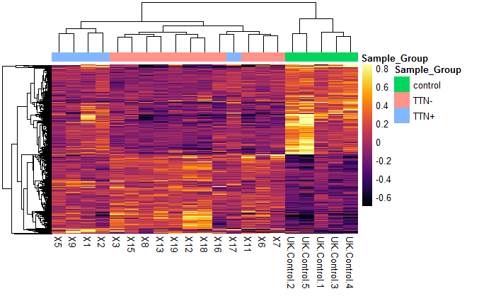

```r
#select top TTN+/TTN- specific genes
topgenes<- c(rownames(posOnly), rownames(negOnly[1:1600,]))

mat<- assay(rld)[topgenes,]
mat<- mat - rowMeans(mat)

#settings for heatmap
subtractFromMin<- -1
subtractFromMax<- 2.5
lengthOut<- 100
mat_breaks<- seq(min(mat-subtractFromMin), max(mat-subtractFromMax), length.out=lengthOut)


#Create metadata- to be used to color code to show which group the sample belongs to
metadata<- data.frame(Sample_Group=PCAData$sampleGroup, row.names=PCAData$name)

#plot heatmap
pheatmap(mat, breaks = mat_breaks, color =inferno(length(mat_breaks-1)), show_rownames = FALSE, annotation_col = metadata, border_color=NA)
```

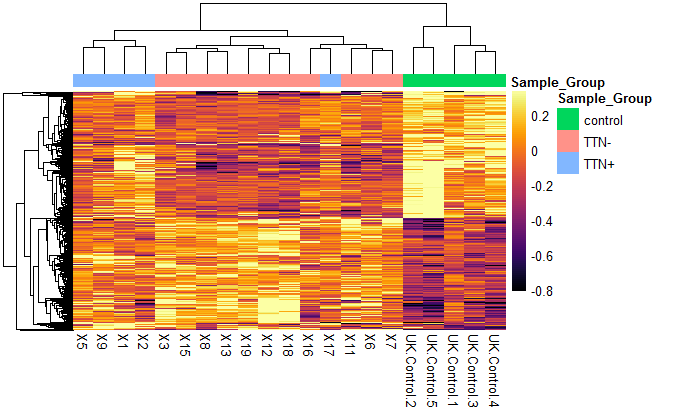

```r
#settings for heatmap
subtractFromMin<- -.9
subtractFromMax<- 3
lengthOut<- 100
mat_breaks<- seq(min(mat-subtractFromMin), max(mat-subtractFromMax), length.out=lengthOut)

#select top 75 DE genes for control vs pos or neg and pos vs neg
topgenes<- c(rownames(posOnly), rownames(negOnly[1:1600,]), rownames(DGERes_posneg))

#Create metadata- to be used to color code to show which group the sample belongs to
metadata<- data.frame(Sample_Group=PCAData$sampleGroup, row.names=PCAData$name)

#plot heatmap
pheatmap(mat, breaks = mat_breaks, color =inferno(length(mat_breaks-1)), show_rownames = FALSE, annotation_col = metadata, border_color=NA)
```

These results mainly used later for comparing to miRNA data

```r
#Set metadata
sampleGroup<- c(rep("CM", 16), rep("control", 5))
meta<-data.frame(Sample=colnames(counts), sampleGroup=sampleGroup)
rownames(meta)<- meta$Sample

#check that counts/meta data has samples in same order
all(rownames(meta) %in% colnames(counts))
all(rownames(meta) == colnames(counts))

#create DESeq2 object
dds<- DESeqDataSetFromMatrix(countData=counts,
                             colData=meta,
                             design=~sampleGroup)

#define levels- so that controls will always be used as reference group
dds$sampleGroup<- relevel(dds$sampleGroup, ref= "control")
```

Normalize data by running DESeq2, visualize sample clustering with PCA plot

```r
#run DE
dds<- DESeq(dds)
```

```
-- replacing outliers and refitting for 45 genes
-- DESeq argument 'minReplicatesForReplace' = 7
-- original counts are preserved in counts(dds)
```

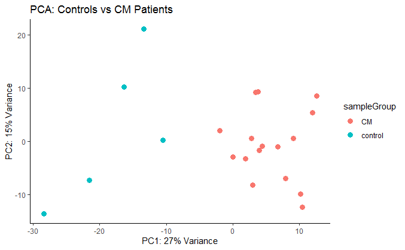

```r
#Normalize using variance stabilizing transformation- DESeq2 function
vsd <- vst(dds, blind=FALSE)
PCAData<-plotPCA(vsd, intgroup="sampleGroup", returnData=TRUE)
PCAData$sampleGroup<- gsub("pos", "TTN+", PCAData$sampleGroup)
PCAData$sampleGroup<- gsub("neg", "TTN-", PCAData$sampleGroup)

p<-ggplot(PCAData, aes(x=PC1, y=PC2, color=sampleGroup))+
  geom_point(size=3)+
  xlab("PC1: 27% Variance")+
  ylab("PC2: 15% Variance")+
  ggtitle("PCA: Controls vs CM Patients")+
  theme_classic()

p
```

Extract results for CM vs controls

```r
res<- as.data.frame(na.omit(results(dds)))
resOrdered<- res[order(res$padj),]
nrow(resOrdered[resOrdered$padj<0.05,])
```

4165 DEGs for Controls vs CM

Plot heatmap for CM vs controls

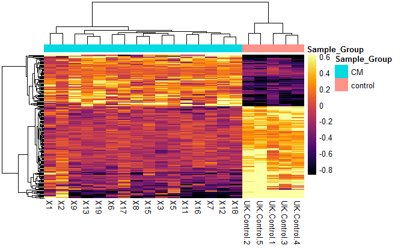

```r
#normalize for heatmap plotting
rld<- rlog(dds)

#Select topgenes
topgenes<- rownames(resOrdered[1:200,])

#Get normalized counts just for topgenes
mat<- assay(rld)[topgenes,]
mat<- mat - rowMeans(mat)

#settings for heatmap
subtractFromMin<- -.7
subtractFromMax<- 2.75
lengthOut<- 100
mat_breaks<- seq(min(mat-subtractFromMin), max(mat-subtractFromMax), length.out=lengthOut)

#Create metadata- to be used to color code to show which group the sample belongs to
metadata<- data.frame(Sample_Group=PCAData$sampleGroup, row.names=PCAData$name)

#plot heatmap
pheatmap(mat, breaks = mat_breaks, color =inferno(length(mat_breaks-1)), show_rownames = FALSE, annotation_col = metadata, border_color = NA)
```

Export DESeq2Results for Contols vs CM

```r
resOrdered$X<- rownames(resOrdered)
write.csv(resOrdered,paste(wd, "DESeq2/Final/DGERes_ControlvsCM.csv", sep =""))
```